# K-Means Clustering

K-Means Clustering is a popular unsupervised machine learning algorithm used for clustering or grouping similar data points together based on their feature similarities. The goal of K-Means is to partition the data into 'k' distinct clusters, where each data point belongs to the cluster with the nearest mean (centroid). The number of clusters, 'k', is predefined by the user.

```python
# Packages / libraries
import os #provides functions for interacting with the operating system
import numpy as np
import pandas as pd
from matplotlib import pyplot as plt
import seaborn as sns
from sklearn.linear_model import LinearRegression
from sklearn.linear_model import LogisticRegression
from sklearn.tree import DecisionTreeClassifier
from sklearn.model_selection import train_test_split
from sklearn.metrics import r2_score, explained_variance_score, confusion_matrix, accuracy_score, classification_report, log_loss
from math import sqrt
from sklearn.metrics import silhouette_samples, silhouette_score
import plotly.express as px
import plotly.graph_objects as go
from mpl_toolkits.mplot3d import Axes3D
from flask import Flask, render_template, request
from sklearn.decomposition import PCA
import matplotlib.pyplot as plt
from IPython.display import clear_output
from sklearn.cluster import KMeans, k_means


%matplotlib inline

# To install sklearn type "pip install numpy scipy scikit-learn" to the anaconda terminal

# To change scientific numbers to float
np.set_printoptions(formatter={'float_kind':'{:f}'.format})

# Increases the size of sns plots
sns.set(rc={'figure.figsize':(8,6)})

# import sys
# !conda list Check the packages installed
```

```python
# import raw data

raw_data = pd.read_csv('/content/drive/MyDrive/Colab Notebooks/bank-additional-full.csv', sep = ";")
raw_data.head(20)
```

|  | age | job | marital | education | default | housing | loan | contact | month | day_of_week | ... | campaign | pdays | previous | poutcome | emp.var.rate | cons.price.idx | cons.conf.idx | euribor3m | nr.employed | y |
| --- | --- | --- | --- | --- | --- | --- | --- | --- | --- | --- | --- | --- | --- | --- | --- | --- | --- | --- | --- | --- | --- |
| 0 | 56 | housemaid | married | basic.4y | no | no | no | telephone | may | mon | ... | 1 | 999 | 0 | nonexistent | 1.1 | 93.994 | -36.4 | 4.857 | 5191.0 | no |
| 1 | 57 | services | married | high.school | unknown | no | no | telephone | may | mon | ... | 1 | 999 | 0 | nonexistent | 1.1 | 93.994 | -36.4 | 4.857 | 5191.0 | no |
| 2 | 37 | services | married | high.school | no | yes | no | telephone | may | mon | ... | 1 | 999 | 0 | nonexistent | 1.1 | 93.994 | -36.4 | 4.857 | 5191.0 | no |
| 3 | 40 | admin. | married | basic.6y | no | no | no | telephone | may | mon | ... | 1 | 999 | 0 | nonexistent | 1.1 | 93.994 | -36.4 | 4.857 | 5191.0 | no |
| 4 | 56 | services | married | high.school | no | no | yes | telephone | may | mon | ... | 1 | 999 | 0 | nonexistent | 1.1 | 93.994 | -36.4 | 4.857 | 5191.0 | no |
| 5 | 45 | services | married | basic.9y | unknown | no | no | telephone | may | mon | ... | 1 | 999 | 0 | nonexistent | 1.1 | 93.994 | -36.4 | 4.857 | 5191.0 | no |
| 6 | 59 | admin. | married | professional.course | no | no | no | telephone | may | mon | ... | 1 | 999 | 0 | nonexistent | 1.1 | 93.994 | -36.4 | 4.857 | 5191.0 | no |
| 7 | 41 | blue-collar | married | unknown | unknown | no | no | telephone | may | mon | ... | 1 | 999 | 0 | nonexistent | 1.1 | 93.994 | -36.4 | 4.857 | 5191.0 | no |
| 8 | 24 | technician | single | professional.course | no | yes | no | telephone | may | mon | ... | 1 | 999 | 0 | nonexistent | 1.1 | 93.994 | -36.4 | 4.857 | 5191.0 | no |
| 9 | 25 | services | single | high.school | no | yes | no | telephone | may | mon | ... | 1 | 999 | 0 | nonexistent | 1.1 | 93.994 | -36.4 | 4.857 | 5191.0 | no |
| 10 | 41 | blue-collar | married | unknown | unknown | no | no | telephone | may | mon | ... | 1 | 999 | 0 | nonexistent | 1.1 | 93.994 | -36.4 | 4.857 | 5191.0 | no |
| 11 | 25 | services | single | high.school | no | yes | no | telephone | may | mon | ... | 1 | 999 | 0 | nonexistent | 1.1 | 93.994 | -36.4 | 4.857 | 5191.0 | no |
| 12 | 29 | blue-collar | single | high.school | no | no | yes | telephone | may | mon | ... | 1 | 999 | 0 | nonexistent | 1.1 | 93.994 | -36.4 | 4.857 | 5191.0 | no |
| 13 | 57 | housemaid | divorced | basic.4y | no | yes | no | telephone | may | mon | ... | 1 | 999 | 0 | nonexistent | 1.1 | 93.994 | -36.4 | 4.857 | 5191.0 | no |
| 14 | 35 | blue-collar | married | basic.6y | no | yes | no | telephone | may | mon | ... | 1 | 999 | 0 | nonexistent | 1.1 | 93.994 | -36.4 | 4.857 | 5191.0 | no |
| 15 | 54 | retired | married | basic.9y | unknown | yes | yes | telephone | may | mon | ... | 1 | 999 | 0 | nonexistent | 1.1 | 93.994 | -36.4 | 4.857 | 5191.0 | no |
| 16 | 35 | blue-collar | married | basic.6y | no | yes | no | telephone | may | mon | ... | 1 | 999 | 0 | nonexistent | 1.1 | 93.994 | -36.4 | 4.857 | 5191.0 | no |
| 17 | 46 | blue-collar | married | basic.6y | unknown | yes | yes | telephone | may | mon | ... | 1 | 999 | 0 | nonexistent | 1.1 | 93.994 | -36.4 | 4.857 | 5191.0 | no |
| 18 | 50 | blue-collar | married | basic.9y | no | yes | yes | telephone | may | mon | ... | 1 | 999 | 0 | nonexistent | 1.1 | 93.994 | -36.4 | 4.857 | 5191.0 | no |
| 19 | 39 | management | single | basic.9y | unknown | no | no | telephone | may | mon | ... | 1 | 999 | 0 | nonexistent | 1.1 | 93.994 | -36.4 | 4.857 | 5191.0 | no |

20 rows × 21 columns

Data Preprocessing

```python
raw_data.isnull().sum()

# Printing the shape
print(raw_data.shape)
```

```
(41188, 21)
```

```python
# Investigate all the elements whithin each Feature

for column in raw_data:
    unique_vals = np.unique(raw_data[column])
    nr_values = len(unique_vals)
    if nr_values < 10:
        print('The number of values for feature {} :{} -- {}'.format(column, nr_values,unique_vals))
    else:
        print('The number of values for feature {} :{}'.format(column, nr_values))
```

```
The number of values for feature age :78
The number of values for feature job :12
The number of values for feature marital :4 -- ['divorced' 'married' 'single' 'unknown']
The number of values for feature education :8 -- ['basic.4y' 'basic.6y' 'basic.9y' 'high.school' 'illiterate'
 'professional.course' 'university.degree' 'unknown']
The number of values for feature default :3 -- ['no' 'unknown' 'yes']
The number of values for feature housing :3 -- ['no' 'unknown' 'yes']
The number of values for feature loan :3 -- ['no' 'unknown' 'yes']
The number of values for feature contact :2 -- ['cellular' 'telephone']
The number of values for feature month :10
The number of values for feature day_of_week :5 -- ['fri' 'mon' 'thu' 'tue' 'wed']
The number of values for feature duration :1544
The number of values for feature campaign :42
The number of values for feature pdays :27
The number of values for feature previous :8 -- [0 1 2 3 4 5 6 7]
The number of values for feature poutcome :3 -- ['failure' 'nonexistent' 'success']
The number of values for feature emp.var.rate :10
The number of values for feature cons.price.idx :26
The number of values for feature cons.conf.idx :26
The number of values for feature euribor3m :316
The number of values for feature nr.employed :11
The number of values for feature y :2 -- ['no' 'yes']
```

```python
# Getting the columns we need

raw_data.columns
```

```
Index(['age', 'job', 'marital', 'education', 'default', 'housing', 'loan',
       'contact', 'month', 'day_of_week', 'duration', 'campaign', 'pdays',
       'previous', 'poutcome', 'emp.var.rate', 'cons.price.idx',
       'cons.conf.idx', 'euribor3m', 'nr.employed', 'y'],
      dtype='object')
```

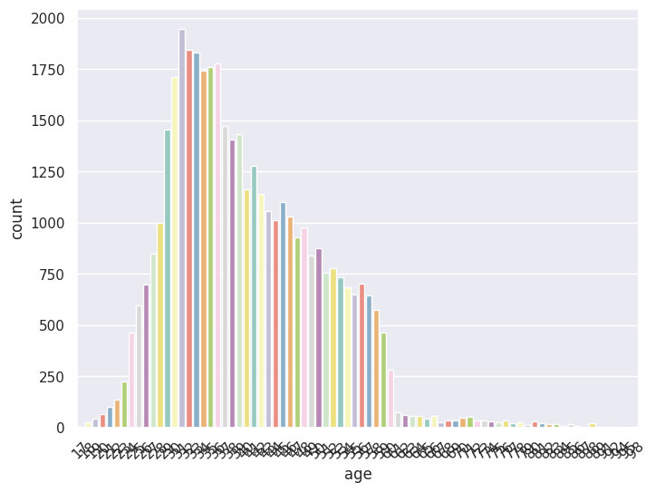

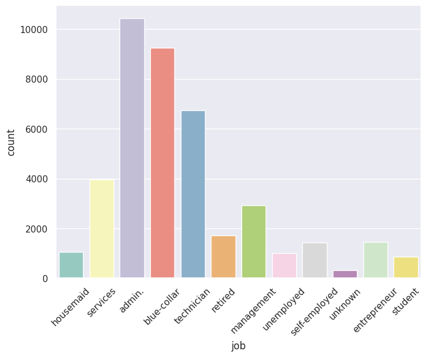

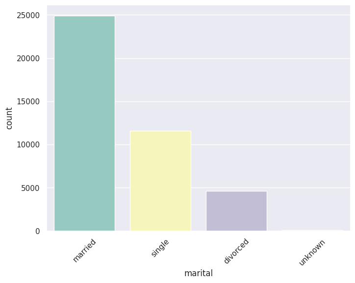

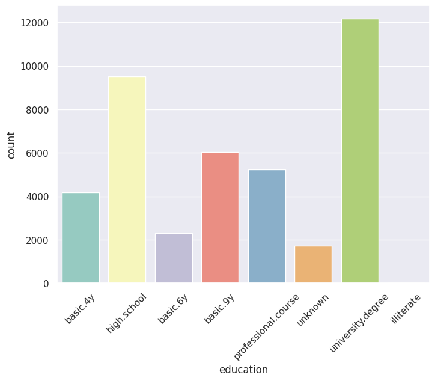

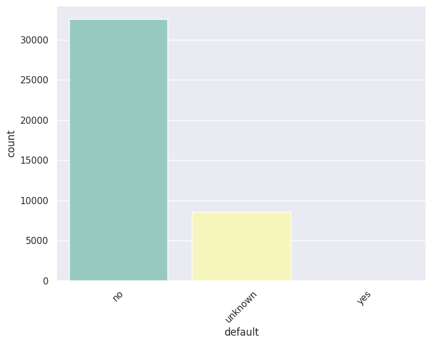

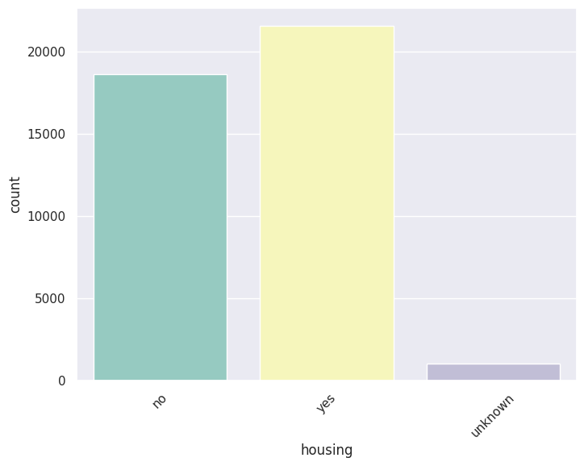

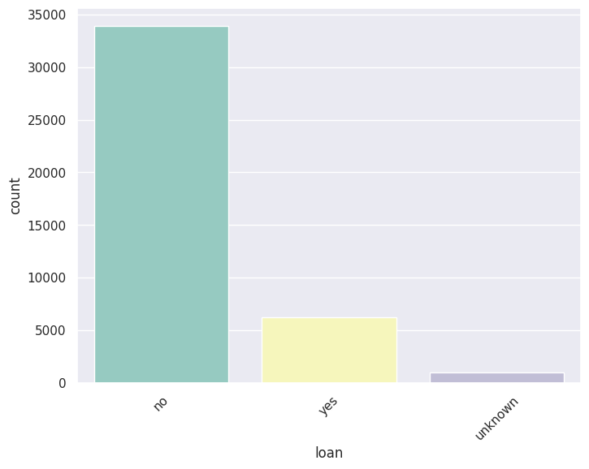

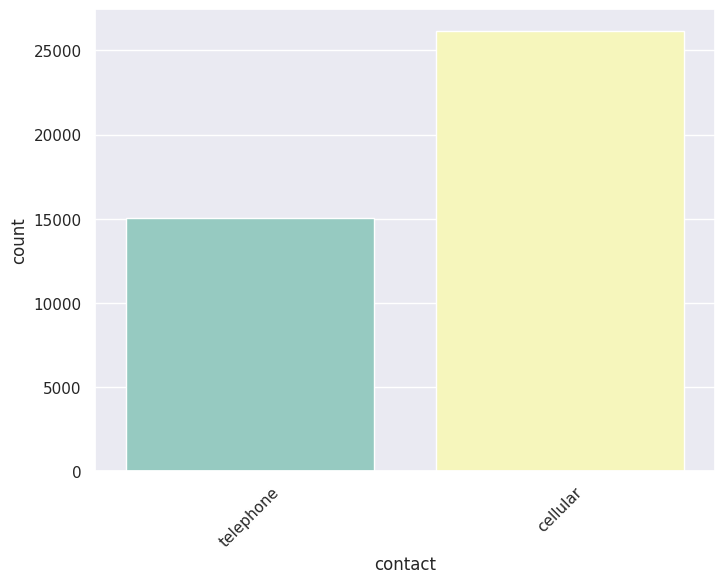

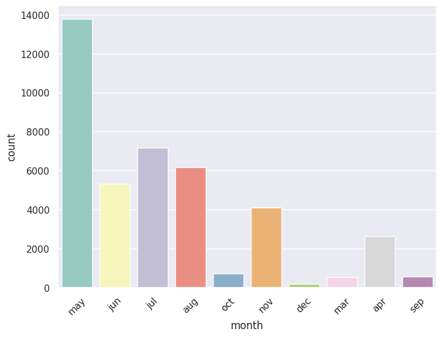

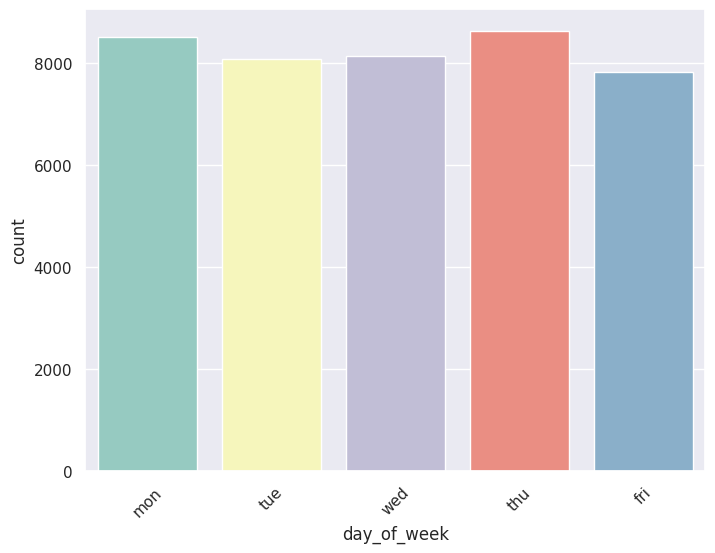

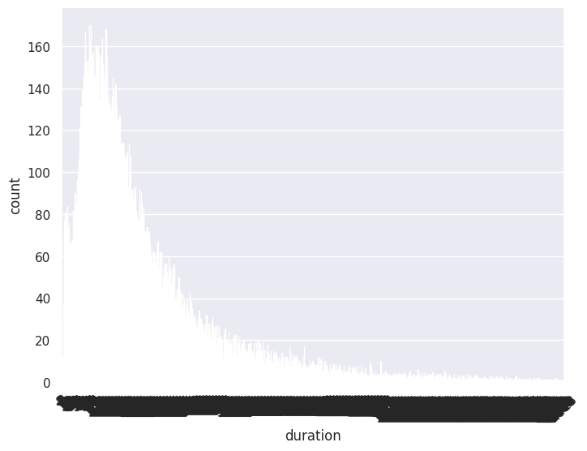

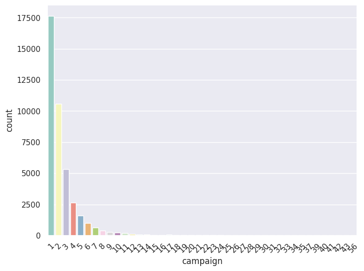

[9 more figures not shown]

```python
# Looping through all the features by our y variable - see if there is relationship

features = ['age', 'job', 'marital', 'education', 'default', 'housing', 'loan',
       'contact', 'month', 'day_of_week', 'duration', 'campaign', 'pdays',
       'previous', 'poutcome', 'emp.var.rate', 'cons.price.idx',
       'cons.conf.idx', 'euribor3m', 'nr.employed', 'y']

for f in features:
  sns.countplot(x = f, data = raw_data, palette = 'Set3')# hue = 'Good Loan')
  plt.xticks(rotation=45)
  plt.show()
```

## Feature Selection

In K-Means Clustering, feature selection refers to the process of choosing the relevant features from the dataset to use for clustering. Selecting appropriate features is important because it directly affects the performance and quality of the clustering results.

```python
features = ['age', 'job', 'marital', 'education', 'default', 'housing', 'loan', 'contact', 'month', 'previous', 'poutcome', 'day_of_week', 'y']
```

## Feature Engineering - Numeric Representation

In K-Means Clustering algorithm development, converting categorical variables into numeric representation is necessary because the algorithm operates based on distance calculations. K-Means uses a distance metric (typically Euclidean distance) to determine the similarity between data points. However, categorical variables do not have a natural distance metric defined between their categories. Therefore, converting categorical variables into numeric representation allows us to incorporate them into the distance calculations.

```python
# Making categorical variables into numeric representation

print(raw_data.shape)

# Making categorical variables into numeric representation
new_raw_data = pd.get_dummies(raw_data, columns = features)

# Notes:
# We can also do this with Label Encoding and OneHotEncoder from the preprocessing library

print(new_raw_data.shape)
# print the shape

new_raw_data.head()
```

```
(41188, 21)
(41188, 149)
```

|  | duration | campaign | pdays | emp.var.rate | cons.price.idx | cons.conf.idx | euribor3m | nr.employed | age_17 | age_18 | ... | poutcome_failure | poutcome_nonexistent | poutcome_success | day_of_week_fri | day_of_week_mon | day_of_week_thu | day_of_week_tue | day_of_week_wed | y_no | y_yes |
| --- | --- | --- | --- | --- | --- | --- | --- | --- | --- | --- | --- | --- | --- | --- | --- | --- | --- | --- | --- | --- | --- |
| 0 | 261 | 1 | 999 | 1.1 | 93.994 | -36.4 | 4.857 | 5191.0 | 0 | 0 | ... | 0 | 1 | 0 | 0 | 1 | 0 | 0 | 0 | 1 | 0 |
| 1 | 149 | 1 | 999 | 1.1 | 93.994 | -36.4 | 4.857 | 5191.0 | 0 | 0 | ... | 0 | 1 | 0 | 0 | 1 | 0 | 0 | 0 | 1 | 0 |
| 2 | 226 | 1 | 999 | 1.1 | 93.994 | -36.4 | 4.857 | 5191.0 | 0 | 0 | ... | 0 | 1 | 0 | 0 | 1 | 0 | 0 | 0 | 1 | 0 |
| 3 | 151 | 1 | 999 | 1.1 | 93.994 | -36.4 | 4.857 | 5191.0 | 0 | 0 | ... | 0 | 1 | 0 | 0 | 1 | 0 | 0 | 0 | 1 | 0 |
| 4 | 307 | 1 | 999 | 1.1 | 93.994 | -36.4 | 4.857 | 5191.0 | 0 | 0 | ... | 0 | 1 | 0 | 0 | 1 | 0 | 0 | 0 | 1 | 0 |

5 rows × 149 columns

```python
print(new_raw_data.isnull().sum())
print(new_raw_data.shape)
```

```
duration           0
campaign           0
pdays              0
emp.var.rate       0
cons.price.idx     0
                  ..
day_of_week_thu    0
day_of_week_tue    0
day_of_week_wed    0
y_no               0
y_yes              0
Length: 149, dtype: int64
(41188, 149)
```

```python
df = new_raw_data.dropna()
print(df.shape)
```

```
(41188, 149)
```

```python
new_raw_data = ((new_raw_data - new_raw_data.min()) / (new_raw_data.max() - new_raw_data.min())) * 9 + 1
print(new_raw_data)
```

```
       duration  campaign  pdays  emp.var.rate  cons.price.idx  cons.conf.idx  \
0      1.477633  1.000000   10.0        9.4375        7.288776       6.422594
1      1.272672  1.000000   10.0        9.4375        7.288776       6.422594
2      1.413583  1.000000   10.0        9.4375        7.288776       6.422594
3      1.276332  1.000000   10.0        9.4375        7.288776       6.422594
4      1.561814  1.000000   10.0        9.4375        7.288776       6.422594
...         ...       ...    ...           ...             ...            ...
41183  1.611224  1.000000   10.0        5.3125       10.000000       1.000000
41184  1.700895  1.000000   10.0        5.3125       10.000000       1.000000
41185  1.345872  1.163636   10.0        5.3125       10.000000       1.000000
41186  1.808865  1.000000   10.0        5.3125       10.000000       1.000000
41187  1.437373  1.327273   10.0        5.3125       10.000000       1.000000

       euribor3m  nr.employed  age_17  age_18  ...  poutcome_failure  \
0       9.616414     8.737618     1.0     1.0  ...               1.0
```

[output cut: 51 more lines]

## Centroid Calculation

```python
def random_centroids(new_raw_data, k):
    centroids = []
    for i in range(k):
        centroid = new_raw_data.apply(lambda x: float(x.sample()))
        centroids.append(centroid)
    return pd.concat(centroids, axis=1)
```

```python
centroids = random_centroids(new_raw_data, 5)
centroids
```

|  | 0 | 1 | 2 | 3 | 4 |
| --- | --- | --- | --- | --- | --- |
| duration | 1.228752 | 1.746645 | 2.279179 | 1.089671 | 1.267182 |
| campaign | 1.163636 | 1.000000 | 1.000000 | 1.000000 | 1.327273 |
| pdays | 10.000000 | 10.000000 | 10.000000 | 10.000000 | 10.000000 |
| emp.var.rate | 10.000000 | 4.000000 | 10.000000 | 4.000000 | 10.000000 |
| cons.price.idx | 8.940764 | 3.427124 | 7.288776 | 5.359704 | 7.288776 |
| ... | ... | ... | ... | ... | ... |
| day_of_week_thu | 1.000000 | 1.000000 | 1.000000 | 10.000000 | 1.000000 |
| day_of_week_tue | 1.000000 | 1.000000 | 1.000000 | 1.000000 | 1.000000 |
| day_of_week_wed | 1.000000 | 10.000000 | 1.000000 | 1.000000 | 10.000000 |
| y_no | 10.000000 | 10.000000 | 1.000000 | 10.000000 | 10.000000 |
| y_yes | 1.000000 | 1.000000 | 1.000000 | 1.000000 | 1.000000 |

149 rows × 5 columns

## Labeling

Labeling in K-Means Clustering refers to assigning cluster labels or identifiers to the data points based on the cluster they belong to. After clustering with the K-Means algorithm, labeling is performed to provide a meaningful representation of the clusters

```python
def get_labels(data, centroids):
    distances = centroids.apply(lambda x: np.sqrt(((data - x) ** 2).sum(axis=1)))
    return distances.idxmin(axis=1)

labels = get_labels(new_raw_data, centroids)
```

```python
def new_centroids(data, labels, k):
    centroids = data.groupby(labels).apply(lambda x: np.exp(np.log(x).mean())).T
    return centroids
```

```python
def plot_clusters(data, labels, centroids, iteration):
    pca = PCA(n_components=2)
    data_2d = pca.fit_transform(data)
    centroids_2d = pca.transform(centroids.T)
    clear_output(wait=True)
    plt.title(f'Iteration {iteration}')
    plt.scatter(x=data_2d[:,0], y=data_2d[:,1], c=labels)
    plt.scatter(x=centroids_2d[:,0], y=centroids_2d[:,1])
    plt.show()
```

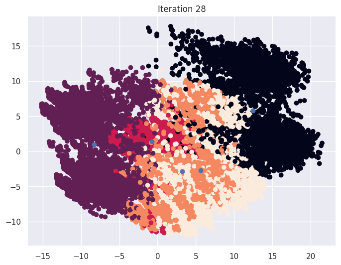

```python
# Visualization of iterations for differences
max_iterations = 100
centroid_count = 5

centroids = random_centroids(new_raw_data, centroid_count)
old_centroids = pd.DataFrame()
iteration = 1

while iteration < max_iterations and not centroids.equals(old_centroids):
    old_centroids = centroids

    labels = get_labels(new_raw_data, centroids)
    centroids = new_centroids(new_raw_data, labels, centroid_count)
    plot_clusters(new_raw_data, labels, centroids, iteration)
    iteration += 1
```

```python
# Prints the clusters it assigned to each observation
print("The clusters are: ", labels)
```

```
The clusters are:  0        1
1        1
2        1
3        1
4        1
        ..
41183    3
41184    3
41185    3
41186    3
41187    0
Length: 41188, dtype: int64
```

## Total clusters in every cluster

```python
unique, counts = np.unique(labels, return_counts=True)
counts = counts.reshape(1,5)

# Creating a datagrame
countscldf = pd.DataFrame(counts, columns = ["Cluster 0","Cluster 1","Cluster 2", "Cluster 3","Cluster 4"])

# display
countscldf
```

|  | Cluster 0 | Cluster 1 | Cluster 2 | Cluster 3 | Cluster 4 |
| --- | --- | --- | --- | --- | --- |
| 0 | 5625 | 14098 | 5987 | 8923 | 6555 |

## Inertia Calculation

In K-Means Clustering, inertia is a metric that measures the quality or compactness of the clusters formed by the algorithm. It is calculated as the sum of squared distances between each data point and its closest centroid. Inertia serves several purposes in K-Means Clustering:

- ```
    Cluster evaluation: Inertia provides a measure of how well the data points within each cluster are concentrated around their respective centroids. A lower inertia value indicates that the data points within each cluster are closer to their centroid, resulting in more compact and tightly grouped clusters. Therefore, inertia serves as a quantitative evaluation metric for the clustering performance.
  ```

- ```
    Optimal number of clusters: Inertia can help determine the optimal number of clusters for a given dataset. When plotting the inertia against the number of clusters, the inertia values typically decrease as the number of clusters increases. However, at a certain point, the rate of decrease in inertia becomes less significant. This point can be used as an indication of the appropriate number of clusters to choose.
  ```

- ```
    Elbow method: The inertia plot is often used in conjunction with the elbow method to select the optimal number of clusters. The elbow method involves plotting the inertia values against different numbers of clusters and looking for the "elbow" point in the graph. The elbow point represents the number of clusters where the decrease in inertia significantly slows down, indicating a balance between cluster compactness and simplicity.
  ```

```python
def calculate_inertia(df, labels, centroids):
    # get the number of clusters
    k = centroids.shape[0]

    # initialize an empty array to store inertia scores
    inertia = np.zeros(k)

    # iterate over each cluster
    for i in range(k):
        # get the data points for this cluster
        cluster_points = df[labels == i]

        # get the distance of each point to the centroid and square it
        distances = np.linalg.norm(cluster_points - centroids.iloc[i], axis=1) ** 2

        # sum the distances to get the inertia for this cluster
        inertia[i] = np.sum(distances)

    return inertia


# assuming data is in a pandas dataframe called 'df'
def calculate_inertia_for_range_of_clusters(df, max_clusters):
    # initialize an empty list to store inertia scores
    inertia_scores = []

    # iterate over each cluster size from 2 to max_clusters
    for k in range(2, max_clusters + 1):
        # randomly initialize k centroids
        centroids = df.sample(n=k)

        # initialize an array to store the labels for each data point
        labels = np.zeros(df.shape[0])

        # iterate until the labels no longer change
        while True:
            # calculate the distance of each data point to each centroid
            distances = np.linalg.norm(df.values[:, np.newaxis, :] - centroids.values, axis=2)

            # assign each data point to the closest centroid
            new_labels = np.argmin(distances, axis=1)

            # if the labels haven't changed, break out of the loop
            if np.array_equal(labels, new_labels):
                break

            # update the labels
            labels = new_labels

            # update the centroids
            for i in range(k):
                centroids.iloc[i] = df[labels == i].mean()

        # calculate the inertia for each cluster
        inertia = calculate_inertia(df, labels, centroids)

        # sum the inertia scores to get the total inertia for this cluster size
        total_inertia = np.sum(inertia)

        # add the total inertia to the list of inertia scores
        inertia_scores.append(total_inertia)

        # print the inertia for this cluster size
        print("The inertia for", k, "clusters is:", total_inertia)

    return inertia_scores
```

```python
inertia_scores = calculate_inertia_for_range_of_clusters(new_raw_data, 19)
```

```
The inertia for 2 clusters is: 22947715.059868835
The inertia for 3 clusters is: 22269918.566044047
The inertia for 4 clusters is: 20928928.842203744
The inertia for 5 clusters is: 20453061.45683165
The inertia for 6 clusters is: 19916132.76045109
The inertia for 7 clusters is: 19333427.50227699
The inertia for 8 clusters is: 19106435.63518413
The inertia for 9 clusters is: 18883344.75829447
The inertia for 10 clusters is: 18808753.18903336
The inertia for 11 clusters is: 18295178.027008273
The inertia for 12 clusters is: 18161596.120421883
The inertia for 13 clusters is: 18045415.204648223
The inertia for 14 clusters is: 17911588.249236576
The inertia for 15 clusters is: 17577599.33209337
The inertia for 16 clusters is: 17566666.236952133
The inertia for 17 clusters is: 17441851.9003814
The inertia for 18 clusters is: 17176600.270268865
The inertia for 19 clusters is: 17065856.044842113
```

```python
print(inertia_scores)
```

[output not shown]

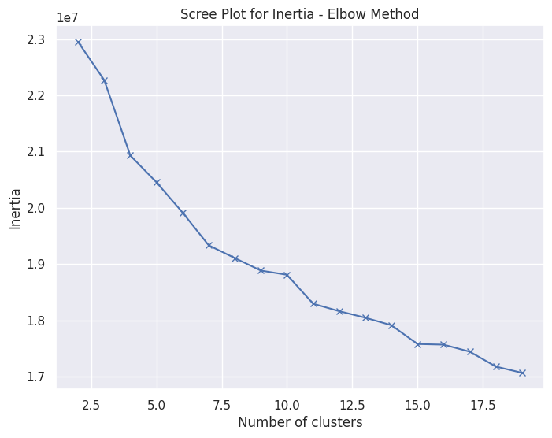

```python
plt.plot(range(2,20), inertia_scores, 'bx-')
plt.xlabel('Number of clusters')
plt.ylabel('Inertia')
plt.title('Scree Plot for Inertia - Elbow Method')
plt.show()
```

```python
print("The clusters are: ", labels)
```

```
The clusters are:  0        1
1        1
2        1
3        1
4        1
        ..
41183    3
41184    3
41185    3
41186    3
41187    0
Length: 41188, dtype: int64
```

## Running Principal Component Analysis (PCA) to Visualize & improve results

- What is it?

  PCA is a dimensionality reduction technique that transforms a number of possibly correlated variables into a smaller number of uncorrelated variables; called principal components

  The goal of PCA is to extract the most important information from the data table by compressing the size of the data set and keeping only the important information; then PCA computes new variables called principal components.
- Additional Info:

  The first principal component is required to have the largest possible variance (inertia) and therefore this component will explain the largest part of the inertia / variance of the data table; hence the less principal components you have the lower the inertia will be after PCA.

  For every new component you add, the inertia will increase since the rotations are always performed in a subspace and the new axes will always explain less inertia than the original components; which are computed to be optimal

  Therefore, inertia should not be the criterium to choose the optimal number of principal component since the lower the components are the lower the inertia will be.

  95% explained variance should be the criterium when choosing the number of principal components

```
Explained variance ratio (first two components): [0.107711 0.064958]
```

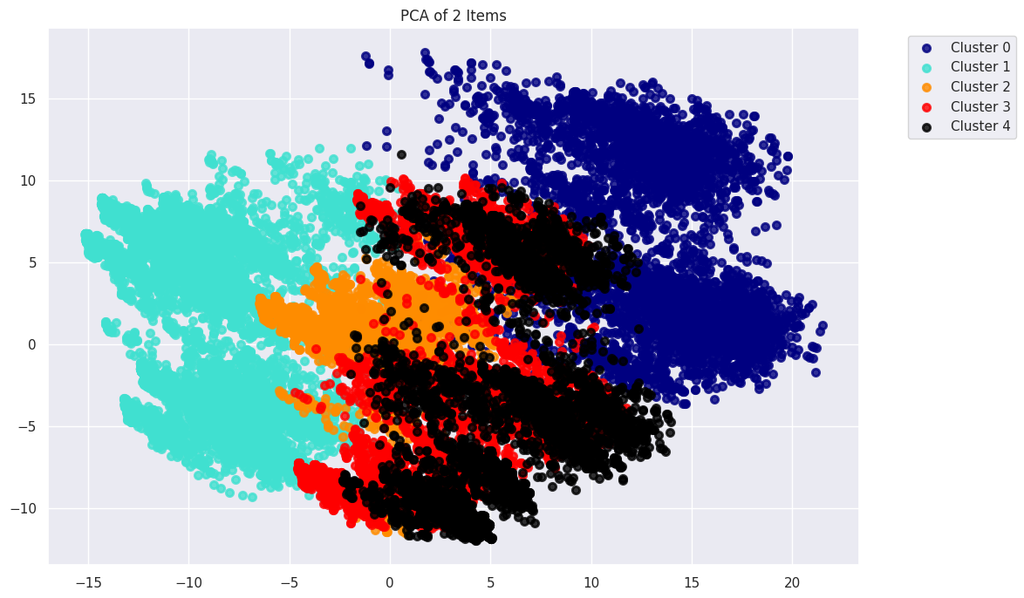

```python
X = new_raw_data
y_num = labels

target_names = ["Cluster 0","Cluster 1","Cluster 2", "Cluster 3","Cluster 4"]

pca = PCA(n_components=2, random_state = 453)
X_r = pca.fit(X).transform(X)


# Percentage of variance explained for each components
print('Explained variance ratio (first two components): %s' % str(pca.explained_variance_ratio_))

# Plotting the data
plt.figure()
plt.figure(figsize=(12,8))
colors = ['navy', 'turquoise', 'darkorange', 'red', 'black']
lw = 2


for color, i, target_name in zip(colors, [0, 1, 2, 3, 4], target_names):
    plt.scatter(X_r[y_num == i, 0], X_r[y_num == i, 1], color=color, alpha=.8, lw=lw,label=target_name)

plt.legend(loc='best', shadow=False, scatterpoints=1)
plt.legend(bbox_to_anchor=(1.05, 1), loc=2, borderaxespad=0.6)
plt.title('PCA of 2 Items')
plt.show()
```

## Why dimensionality reduction could help k-means perform better:

- ```
    Kmeans tries to find the least squares partition of the data while PCA finds the least squares cluster membership vector. The first eigenvector has the largest variance (smallest inertia), hence splitting on this vector (which shows the cluster membership - not input data coordinates) means maximization of cluster variance; better fit for Kmeans.
  ```

- ```
      By maximizing between cluster variance, you minimize within-cluster variance. Therefore, applying PCA before clustering could potentially help you get better clusters (with more variance) in Kmeans.
  ```

```
Total Variance in our dataset is:  609.3482701153478
The 95% variance we want to have is:  578.8808566095803

Number of components needed to explain 95% variance: 59
Variance explain with 30 n_components:  505.4954392668035
Variance explain with 35 n_components:  523.4919050945292
Variance explain with 40 n_components:  539.2798612255256
Variance explain with 41 n_components:  542.1004882861313
Variance explain with 50 n_components:  563.6481078970816
Variance explain with 53 n_components:  569.6674317988341
Variance explain with 55 n_components:  573.5224708121858
Variance explain with 59 n_components:  580.5481855667406
```

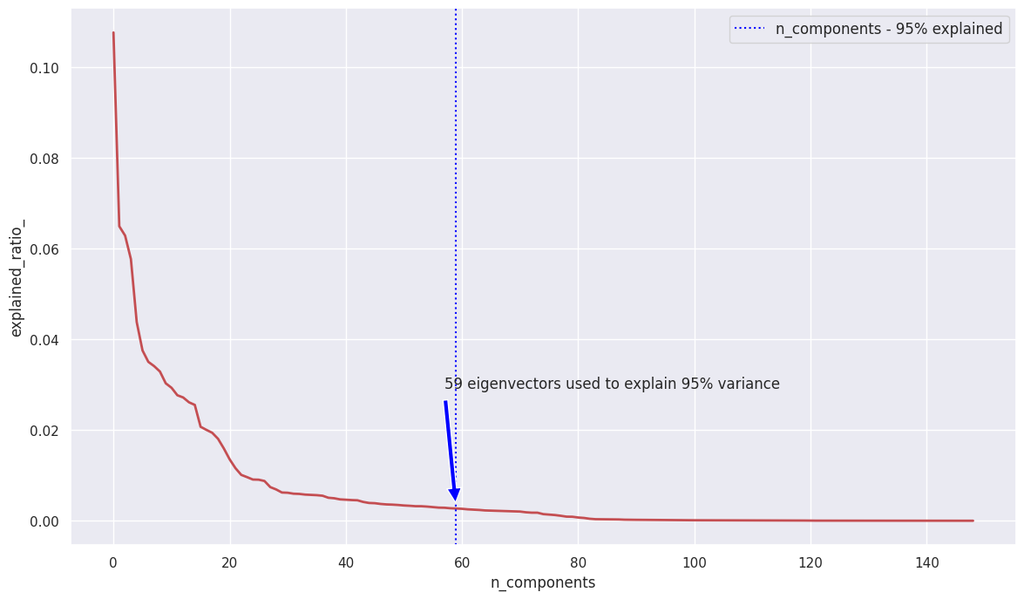

```python
# Trying with Dimentionality reduction and then Kmeans

n_components = new_raw_data.shape[1]

# Running PCA with all components
pca = PCA(n_components=n_components, random_state = 453)
X_r = pca.fit(X).transform(X)


# Calculating the 95% Variance
total_variance = sum(pca.explained_variance_)
print("Total Variance in our dataset is: ", total_variance)
var_95 = total_variance * 0.95
print("The 95% variance we want to have is: ", var_95)
print("")

# Creating a df with the components and explained variance
a = zip(range(0,n_components), pca.explained_variance_)
a = pd.DataFrame(a, columns=["PCA Comp", "Explained Variance"])

total_var = sum(pca.explained_variance_)
desired_var = 0.95 * total_var

n_components = 1
cumulative_var = pca.explained_variance_[0]

while cumulative_var < desired_var:
    cumulative_var += pca.explained_variance_[n_components]
    n_components += 1

print(f"Number of components needed to explain 95% variance: {n_components}")



# Trying to hit 95%
a = zip(range(0,n_components), pca.explained_variance_)
a = pd.DataFrame(a, columns=["PCA Comp", "Explained Variance"])

print("Variance explain with 30 n_components: ", sum(a["Explained Variance"][0:30]))
print("Variance explain with 35 n_components: ", sum(a["Explained Variance"][0:35]))
print("Variance explain with 40 n_components: ", sum(a["Explained Variance"][0:40]))
print("Variance explain with 41 n_components: ", sum(a["Explained Variance"][0:41]))
print("Variance explain with 50 n_components: ", sum(a["Explained Variance"][0:50]))
print("Variance explain with 53 n_components: ", sum(a["Explained Variance"][0:53]))
print("Variance explain with 55 n_components: ", sum(a["Explained Variance"][0:55]))
print("Variance explain with 59 n_components: ", sum(a["Explained Variance"][0:59]))


# Plotting the Data
plt.figure(1, figsize=(14, 8))
plt.plot(pca.explained_variance_ratio_, linewidth=2, c="r")
plt.xlabel('n_components')
plt.ylabel('explained_ratio_')

# Plotting line with 95% e.v.
plt.axvline(59, linestyle=':', label='n_components - 95% explained', c ="blue")
plt.legend(prop=dict(size=12))

# adding arrow
plt.annotate('59 eigenvectors used to explain 95% variance', xy=(59, pca.explained_variance_ratio_[59]),
             xytext=(57, pca.explained_variance_ratio_[10]),
            arrowprops=dict(facecolor='blue', shrink=0.05))

plt.show()
```

```python
df = raw_data.copy()
print(df.shape)
print(df.head(10))
```

```
(41188, 21)
   age          job  marital            education  default housing loan  \
0   56    housemaid  married             basic.4y       no      no   no
1   57     services  married          high.school  unknown      no   no
2   37     services  married          high.school       no     yes   no
3   40       admin.  married             basic.6y       no      no   no
4   56     services  married          high.school       no      no  yes
5   45     services  married             basic.9y  unknown      no   no
6   59       admin.  married  professional.course       no      no   no
7   41  blue-collar  married              unknown  unknown      no   no
8   24   technician   single  professional.course       no     yes   no
9   25     services   single          high.school       no     yes   no

     contact month day_of_week  ...  campaign  pdays  previous     poutcome  \
0  telephone   may         mon  ...         1    999         0  nonexistent
```

[output cut: 23 more lines]

```python
print(labels)
```

```
0        1
1        1
2        1
3        1
4        1
        ..
41183    3
41184    3
41185    3
41186    3
41187    0
Length: 41188, dtype: int64
```

```python
df['cluster'] = labels
print(df.shape)
print(df.head(10))
```

```
(41188, 22)
   age          job  marital            education  default housing loan  \
0   56    housemaid  married             basic.4y       no      no   no
1   57     services  married          high.school  unknown      no   no
2   37     services  married          high.school       no     yes   no
3   40       admin.  married             basic.6y       no      no   no
4   56     services  married          high.school       no      no  yes
5   45     services  married             basic.9y  unknown      no   no
6   59       admin.  married  professional.course       no      no   no
7   41  blue-collar  married              unknown  unknown      no   no
8   24   technician   single  professional.course       no     yes   no
9   25     services   single          high.school       no     yes   no

     contact month day_of_week  ...  pdays  previous     poutcome  \
0  telephone   may         mon  ...    999         0  nonexistent
```

[output cut: 35 more lines]

```python
print(df.columns)
```

```
Index(['age', 'job', 'marital', 'education', 'default', 'housing', 'loan',
       'contact', 'month', 'day_of_week', 'duration', 'campaign', 'pdays',
       'previous', 'poutcome', 'emp.var.rate', 'cons.price.idx',
       'cons.conf.idx', 'euribor3m', 'nr.employed', 'y', 'cluster'],
      dtype='object')
```

```python
df = df.drop(['poutcome', 'emp.var.rate', 'cons.price.idx',
       'cons.conf.idx', 'euribor3m', 'nr.employed', 'pdays'], axis=1)
print(df.columns)
```

```
Index(['age', 'job', 'marital', 'education', 'default', 'housing', 'loan',
       'contact', 'month', 'day_of_week', 'duration', 'campaign', 'previous',
       'y', 'cluster'],
      dtype='object')
```

```python
con_data.columns
```

```
Index(['_id', 'age', 'job', 'marital', 'education', 'default', 'housing',
       'loan', 'contact', 'month', 'day_of_week', 'duration', 'campaign',
       'pdays', 'previous', 'poutcome', 'emp.var.rate', 'cons.price.idx',
       'cons.conf.idx', 'euribor3m', 'nr.employed', 'y'],
      dtype='object')
```

```python
con_data = con_data.drop(['_id', 'duration', 'campaign',
       'pdays', 'previous', 'poutcome', 'emp.var.rate', 'cons.price.idx',
       'cons.conf.idx', 'euribor3m', 'nr.employed'], axis=1)
con_data.columns
```

```
Index(['age', 'job', 'marital', 'education', 'default', 'housing', 'loan',
       'contact', 'month', 'day_of_week', 'y'],
      dtype='object')
```

```python
con_data['cluster'] = labels
print(con_data.shape)
print(con_data.head(10))
```

```
(41188, 12)
   age  job  marital  education  default  housing  loan  contact  month  \
0   56    0        0          0        0        0     0        1      0
1   57    1        0          1        1        0     0        1      0
2   37    1        0          1        0        2     0        1      0
3   40    2        0          2        0        0     0        1      0
4   56    1        0          1        0        0     2        1      0
5   45    1        0          3        1        0     0        1      0
6   59    2        0          4        0        0     0        1      0
7   41    3        0          5        1        0     0        1      0
8   24    4        1          4        0        2     0        1      0
9   25    1        1          1        0        2     0        1      0

   day_of_week  y  cluster
0            0  0        1
1            0  0        1
2            0  0        1
3            0  0        1
4            0  0        1
5            0  0        1
6            0  0        1
7            0  0        1
8            0  0        1
9            0  0        1
```